# 📊 Data Visualization Tutorial (Matplotlib, Seaborn, Plotly)

This notebook explores how to create effective visualizations using Python’s most popular libraries: `matplotlib`, `seaborn`, and `plotly`.

## 📚 Table of Contents

1. Setup and Dataset Overview
2. Bar Chart
3. Line Chart
4. Scatter Plot
5. Histogram & KDE
6. Box Plot & Violin Plot
7. Heatmap & Correlation
8. Interactive Plotly Charts
9. Final Summary

Each chart type includes:

- 🔍 *What is it?*
- ❓ *When to use it?*
- 🛠 *How to code it?*
- 📈 *Insights from output*

# 📘 Chapter 1: Setup and Dataset Overview

### 🎯 Goal:

Set up the environment and load the cleaned Superstore dataset. This dataset will be used throughout the tutorial to create insightful visualizations.

### 📦 Import Required Libraries

```python
import pandas as pd
import matplotlib.pyplot as plt
import seaborn as sns
import numpy as np

# Display plots inside notebook
%matplotlib inline

# Set plot styles
sns.set(style='whitegrid')
plt.rcParams['figure.figsize'] = (10, 6)
```

### 📂 Load the Cleaned Superstore Dataset

## 🧼 Dataset Setup & Preprocessing

We’ll load the cleaned Superstore dataset and ensure all column names are lowercase with underscores instead of spaces or dashes for consistency.

```python
import pandas as pd
import matplotlib.pyplot as plt
import seaborn as sns
import plotly.express as px

# Load cleaned Superstore dataset
df = pd.read_csv("superstore_cleaned.csv")

# Standardize column names
df.columns = df.columns.str.lower().str.replace(' ', '_').str.replace('-', '_')

# Convert dates
df['order_date'] = pd.to_datetime(df['order_date'])
df['ship_date'] = pd.to_datetime(df['ship_date'])

df.head()
```

|  | order_id | order_date | ship_date | ship_mode | customer_id | customer_name | segment | state | city | category | sub_category | product_name | sales | quantity | discount | profit |
| --- | --- | --- | --- | --- | --- | --- | --- | --- | --- | --- | --- | --- | --- | --- | --- | --- |
| 0 | CA-2016-152156 | 2016-11-08 | 2016-11-11 | Second Class | CG-12520 | Claire Gute | Consumer | Kentucky | Henderson | Furniture | Bookcases | Bush Somerset Collection Bookcase | 261.9600 | 2 | 0.00 | 41.9136 |
| 1 | CA-2016-152156 | 2016-11-08 | 2016-11-11 | Second Class | CG-12520 | Claire Gute | Consumer | Kentucky | Henderson | Furniture | Chairs | Hon Deluxe Fabric Upholstered Stacking Chairs,... | 731.9400 | 3 | 0.00 | 219.5820 |
| 2 | CA-2016-138688 | 2016-06-12 | 2016-06-16 | Second Class | DV-13045 | Darrin Van Huff | Corporate | California | Los Angeles | Office Supplies | Labels | Self-Adhesive Address Labels for Typewriters b... | 14.6200 | 2 | 0.00 | 6.8714 |
| 3 | US-2015-108966 | 2015-10-11 | 2015-10-18 | Standard Class | SO-20335 | Sean O'Donnell | Consumer | Florida | Fort Lauderdale | Furniture | Tables | Bretford CR4500 Series Slim Rectangular Table | 957.5775 | 5 | 0.45 | -383.0310 |
| 4 | US-2015-108966 | 2015-10-11 | 2015-10-18 | Standard Class | SO-20335 | Sean O'Donnell | Consumer | Florida | Fort Lauderdale | Office Supplies | Storage | Eldon Fold 'N Roll Cart System | 22.3680 | 2 | 0.20 | 2.5164 |

```python
df.columns = df.columns.str.strip().str.replace(' ', '_').str.replace('-', '_').str.lower()
```

### 👁️ Quick Look at the Dataset

```python
df.info()
```

```
<class 'pandas.core.frame.DataFrame'>
RangeIndex: 9994 entries, 0 to 9993
Data columns (total 16 columns):
 #   Column         Non-Null Count  Dtype
---  ------         --------------  -----
 0   order_id       9994 non-null   object
 1   order_date     9994 non-null   datetime64[ns]
 2   ship_date      9994 non-null   datetime64[ns]
 3   ship_mode      9994 non-null   object
 4   customer_id    9994 non-null   object
 5   customer_name  9994 non-null   object
 6   segment        9994 non-null   object
 7   state          9994 non-null   object
 8   city           9994 non-null   object
 9   category       9994 non-null   object
 10  sub_category   9994 non-null   object
 11  product_name   9994 non-null   object
 12  sales          9994 non-null   float64
 13  quantity       9994 non-null   int64
 14  discount       9994 non-null   float64
 15  profit         9994 non-null   float64
dtypes: datetime64[ns](2), float64(3), int64(1), object(10)
memory usage: 1.2+ MB
```

### 📊 Summary Statistics (Numerical Columns)

```python
df.describe()
```

|  | order_date | ship_date | sales | quantity | discount | profit |
| --- | --- | --- | --- | --- | --- | --- |
| count | 9994 | 9994 | 9994.000000 | 9994.000000 | 9994.000000 | 9994.000000 |
| mean | 2016-04-30 00:07:12.259355648 | 2016-05-03 23:06:58.571142912 | 229.858001 | 3.789574 | 0.156203 | 28.656896 |
| min | 2014-01-03 00:00:00 | 2014-01-07 00:00:00 | 0.444000 | 1.000000 | 0.000000 | -6599.978000 |
| 25% | 2015-05-23 00:00:00 | 2015-05-27 00:00:00 | 17.280000 | 2.000000 | 0.000000 | 1.728750 |
| 50% | 2016-06-26 00:00:00 | 2016-06-29 00:00:00 | 54.490000 | 3.000000 | 0.200000 | 8.666500 |
| 75% | 2017-05-14 00:00:00 | 2017-05-18 00:00:00 | 209.940000 | 5.000000 | 0.200000 | 29.364000 |
| max | 2017-12-30 00:00:00 | 2018-01-05 00:00:00 | 22638.480000 | 14.000000 | 0.800000 | 8399.976000 |
| std | NaN | NaN | 623.245101 | 2.225110 | 0.206452 | 234.260108 |

### ❓ Check for Missing Values

```python
df.isna().sum()
```

```
order_id         0
order_date       0
ship_date        0
ship_mode        0
customer_id      0
customer_name    0
segment          0
state            0
city             0
category         0
sub_category     0
product_name     0
sales            0
quantity         0
discount         0
profit           0
dtype: int64
```

### 📋 Dataset Columns

```python
df.columns.tolist()
```

```
['order_id',
 'order_date',
 'ship_date',
 'ship_mode',
 'customer_id',
 'customer_name',
 'segment',
 'state',
 'city',
 'category',
 'sub_category',
 'product_name',
 'sales',
 'quantity',
 'discount',
 'profit']
```

### 🔢 Unique Value Count in Each Column

```python
df.nunique()
```

```
order_id         5009
order_date       1237
ship_date        1334
ship_mode           4
customer_id       793
customer_name     793
segment             3
state              49
city              531
category            3
sub_category       17
product_name     1850
sales            5825
quantity           14
discount           12
profit           7287
dtype: int64
```

# 📊 Chapter 2: Univariate Analysis

### 🎯 Goal:

Explore the distribution of single variables using common univariate plots:

- Histogram
- Density Plot
- Box Plot
- Bar Plot
- Pie Chart

**Libraries:** Matplotlib, Seaborn, Plotly Express

## 📈 Histogram

- *What: A histogram is a graphical representation of the distribution of numerical data.*
- *Why: To understand the frequency distribution of a variable.*
- *When to use: Analyze distribution shape, detect skewness, and identify outliers.*

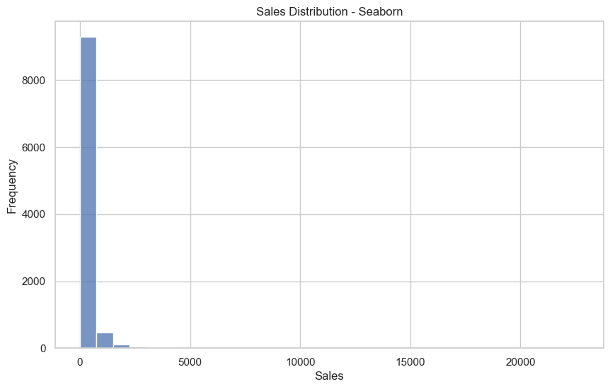

```python
# Seaborn histogram for Sales
sns.histplot(df['sales'], bins=30, kde=False)
plt.title("Sales Distribution - Seaborn")
plt.xlabel("Sales")
plt.ylabel("Frequency")
plt.show()
```

📌 **Insight:** Most sales are low-value; the distribution is right-skewed.

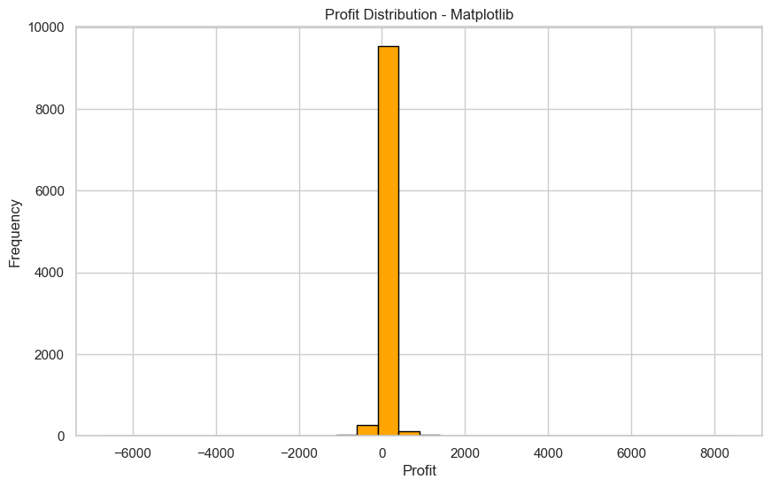

```python
# Matplotlib histogram for Profit
plt.hist(df['profit'], bins=30, color='orange', edgecolor='black')
plt.title("Profit Distribution - Matplotlib")
plt.xlabel("Profit")
plt.ylabel("Frequency")
plt.show()
```

📌 **Insight:** Profit includes both gains and losses; losses appear as a left tail.

```python
# Plotly histogram for Quantity
fig = px.histogram(df, x='quantity', nbins=20, title="Quantity Distribution - Plotly")
fig.show()
```

📌 **Insight:** Quantity per order is mostly small, indicating few items per purchase.

## 🛣️ Density Plot

- *What: A density plot is a smoothed curve indicating the distribution of data.*
- *Why: To visualize the probability distribution.*
- *When to use: Compare smooth distributions and detect multimodality.*

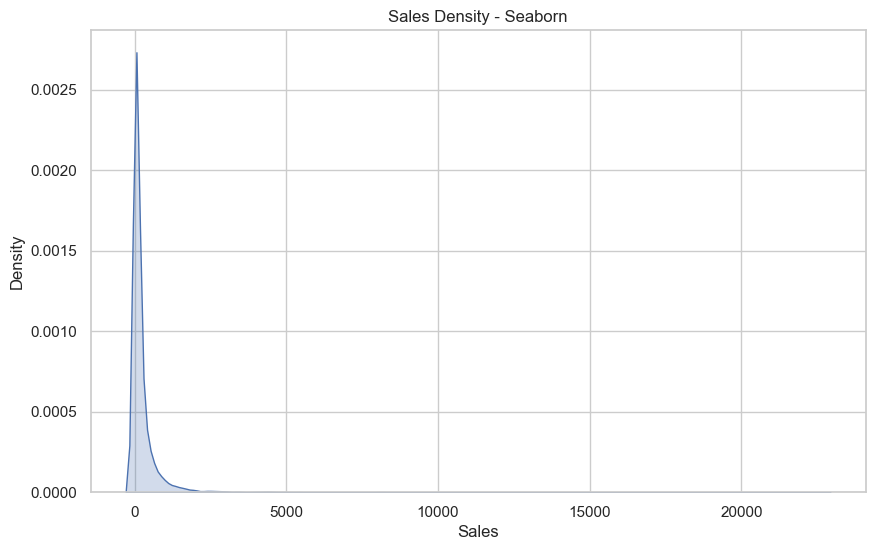

```python
# Seaborn KDE for Sales
sns.kdeplot(df['sales'], fill=True)
plt.title("Sales Density - Seaborn")
plt.xlabel("Sales")
plt.show()
```

```python
# Plotly density-like histogram for Profit
fig = px.histogram(df, x='profit', nbins=30, histnorm='density', title="Profit Density - Plotly")
fig.show()
```

📌 **Insight:** The smoothed density underscores tails and any secondary peaks.

## 📦 Box Plot

- *What: A box plot shows the five-number summary (min, Q1, median, Q3, max).*
- *Why: To highlight distribution spread and outliers.*
- *When to use: Compare distributions across categories and detect anomalies.*

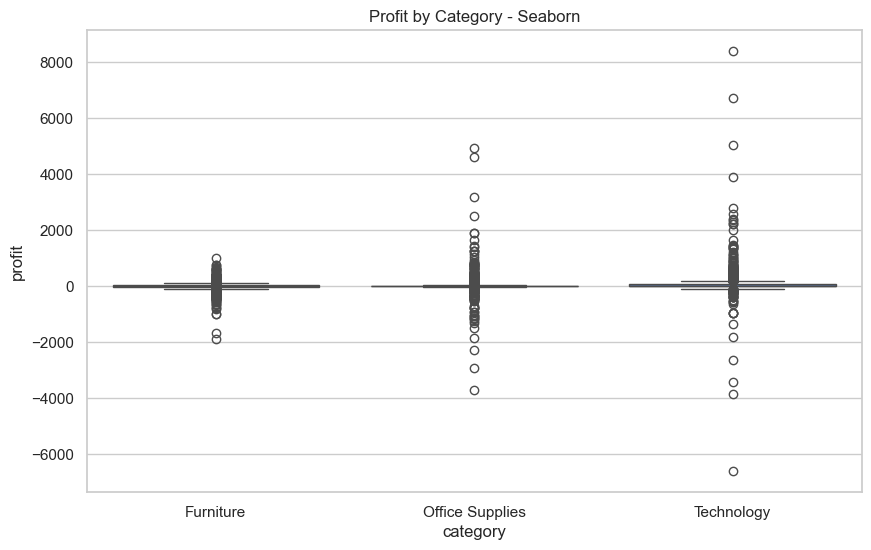

```python
# Seaborn box plot: Profit by Category
sns.boxplot(data=df, x='category', y='profit')
plt.title("Profit by Category - Seaborn")
plt.show()
```

```python
# Plotly box plot: Sales by Ship Mode
fig = px.box(df, x='ship_mode', y='sales', title="Sales by Ship Mode - Plotly")
fig.show()
```

## 📊 Bar Plot

- *What: A bar plot displays categorical counts or aggregates.*
- *Why: To compare values across categories.*
- *When to use: Show counts or summary (sum, mean) of categories.*

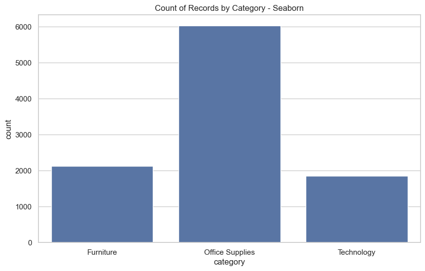

```python
# Seaborn count plot for Category
sns.countplot(data=df, x='category')
plt.title("Count of Records by Category - Seaborn")
plt.show()
```

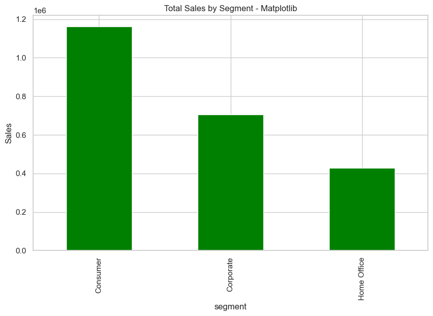

```python
# Matplotlib bar: Total Sales by Segment
sales_by_segment = df.groupby('segment')['sales'].sum()
sales_by_segment.plot(kind='bar', color='green')
plt.title("Total Sales by Segment - Matplotlib")
plt.ylabel("Sales")
plt.show()
```

```python
# Plotly bar: Top 5 States by Sales
top_states = df.groupby('state')['sales'].sum().nlargest(5).reset_index()
fig = px.bar(top_states, x='state', y='sales', title="Top 5 States by Sales - Plotly")
fig.show()
```

📌 **Insight:** California leads sales, followed by New York and Texas.

## 🥧 Pie Chart

- *What: A pie chart shows parts of a whole as slices.*
- *Why: To illustrate percentage contribution of categories.*
- *When to use: Few categories with clear part-to-whole relationships.*

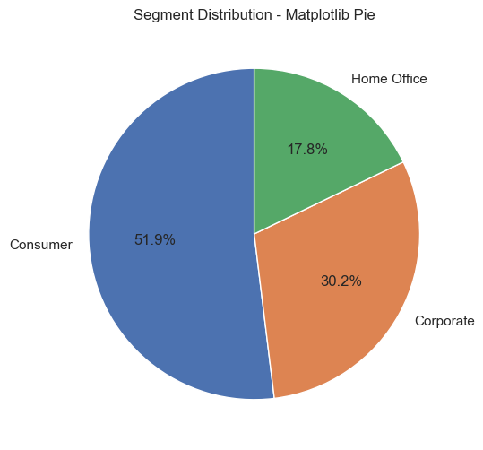

```python
# Matplotlib pie for Segment
seg_counts = df['segment'].value_counts()
seg_counts.plot(kind='pie', autopct='%1.1f%%', startangle=90)
plt.title("Segment Distribution - Matplotlib Pie")
plt.ylabel("")
plt.show()
```

```python
ship_counts = df['ship_mode'].value_counts().reset_index()
ship_counts
```

|  | ship_mode | count |
| --- | --- | --- |
| 0 | Standard Class | 5968 |
| 1 | Second Class | 1945 |
| 2 | First Class | 1538 |
| 3 | Same Day | 543 |

```python
# Plotly pie for Ship Mode
ship_counts = df['ship_mode'].value_counts().reset_index()
fig = px.pie(ship_counts, names='ship_mode', values='count', title="Ship Mode Distribution - Plotly Pie")
fig.show()
```

📌 **Insight:** Most orders use Standard Class shipping, reflecting standard delivery preference.

# 🔗 Chapter 3: Bivariate Analysis

### 🎯 Goal:

Explore relationships between **two variables** using various bivariate plots:

- Scatter Plot
- Line Plot
- Correlation Heatmap
- Strip and Swarm Plots

We will use **Matplotlib**, **Seaborn**, and **Plotly Express** to explore visual relationships between variables.

## 📌 Scatter Plot

- *What:* A scatter plot shows the relationship between two continuous variables.
- *Why:* To detect patterns, clusters, or correlations.
- *When to use:* When analyzing numeric variable interactions or trend strength.

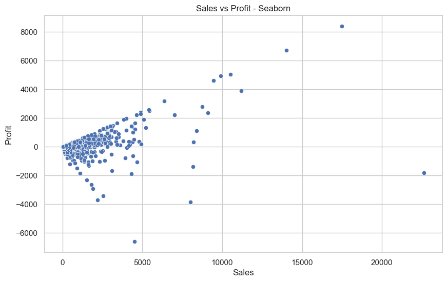

```python
sns.scatterplot(data=df, x='sales', y='profit')
plt.title("Sales vs Profit - Seaborn")
plt.xlabel("Sales")
plt.ylabel("Profit")
plt.show()
```

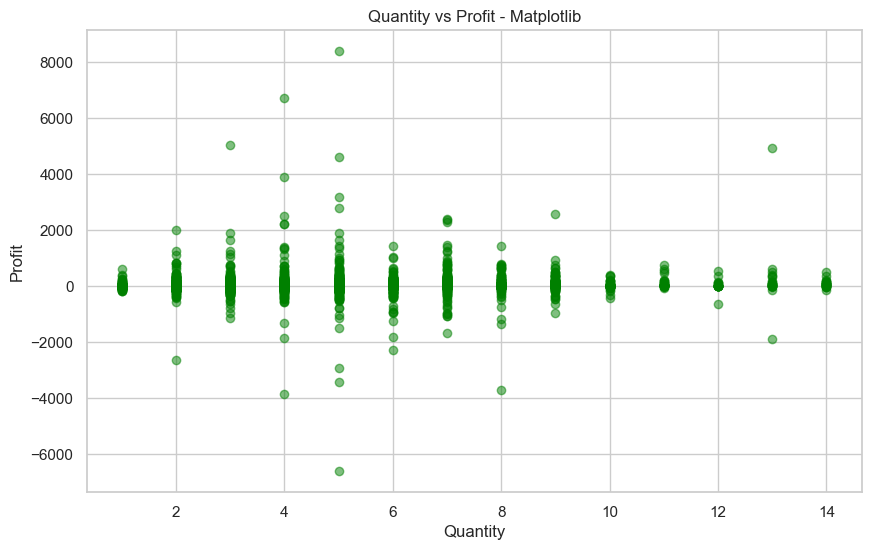

```python
plt.scatter(df['quantity'], df['profit'], alpha=0.5, color='green')
plt.title("Quantity vs Profit - Matplotlib")
plt.xlabel("Quantity")
plt.ylabel("Profit")
plt.show()
```

```python
fig = px.scatter(df, x='sales', y='discount', color='category',
                 title="Sales vs Discount by Category - Plotly", opacity=0.7)
fig.show()
```

📌 **Insight:** Most profitable transactions are at low discount levels. Higher discounts often lead to losses.

## 📈 Line Plot

- *What:* A line plot shows trends of a variable over a sequential axis like time.
- *Why:* To analyze performance and variation over time.
- *When to use:* Use line plots for temporal data or comparisons across time intervals.

```python
df['order_date'] = pd.to_datetime(df['order_date'])
```

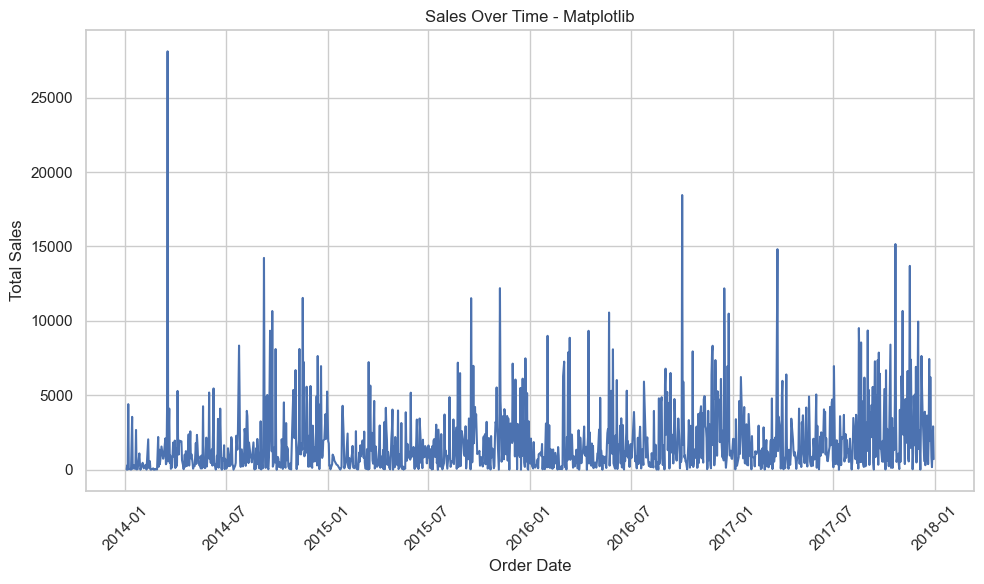

```python
df_by_date = df.groupby('order_date')['sales'].sum().reset_index()
plt.plot(df_by_date['order_date'], df_by_date['sales'])
plt.title("Sales Over Time - Matplotlib")
plt.xlabel("Order Date")
plt.ylabel("Total Sales")
plt.xticks(rotation=45)
plt.tight_layout()
plt.show()
```

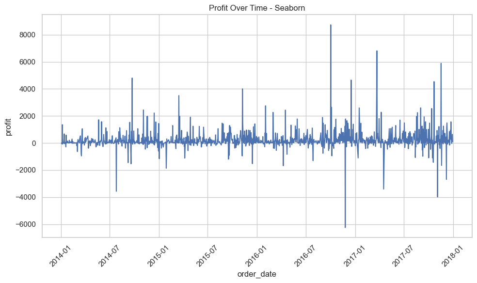

```python
df_by_date = df.groupby('order_date')['profit'].sum().reset_index()
sns.lineplot(data=df_by_date, x='order_date', y='profit')
plt.title("Profit Over Time - Seaborn")
plt.xticks(rotation=45)
plt.tight_layout()
plt.show()
```

```python
df_by_date = df.groupby('order_date')['discount'].mean().reset_index()
fig = px.line(df_by_date, x='order_date', y='discount', title="Average Discount Over Time - Plotly")
fig.show()
```

📌 **Insight:** Sales and profits show seasonal spikes, while discount averages remain relatively flat.

## 🔥 Correlation Heatmap

- *What:* A heatmap displays correlation values between numeric variables.
- *Why:* To identify potential predictors or multicollinearity.
- *When to use:* When exploring linear relationships among multiple numeric features.

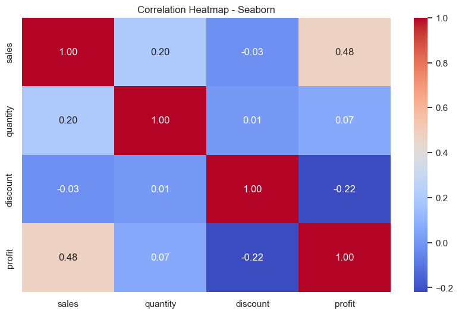

```python
corr = df[['sales', 'quantity', 'discount', 'profit']].corr()
sns.heatmap(corr, annot=True, cmap='coolwarm', fmt='.2f')
plt.title("Correlation Heatmap - Seaborn")
plt.show()
```

```python
fig = px.imshow(corr, text_auto=True, color_continuous_scale='RdBu_r',
                 title="Correlation Heatmap - Plotly")
fig.show()
```

📌 **Insight:** Discount and Profit are negatively correlated, while Quantity and Sales show weaker relationships.

## 🎯 Strip & Swarm Plots

- *What:* These show individual observations for a categorical variable against a numeric variable.
- *Why:* To observe spread and overlapping data points.
- *When to use:* When you want to see actual data points and their distribution within categories.

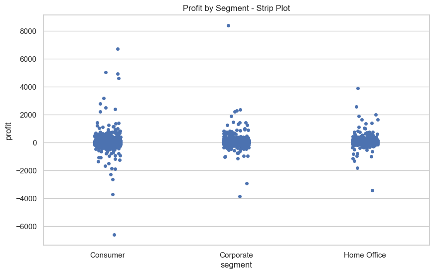

```python
sns.stripplot(data=df, x='segment', y='profit', jitter=True)
plt.title("Profit by Segment - Strip Plot")
plt.show()
```

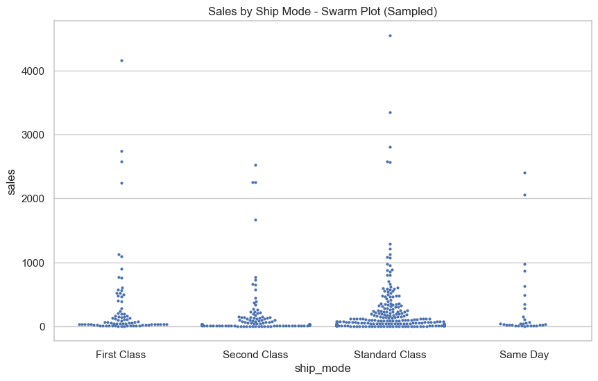

```python
sns.swarmplot(data=df.sample(500, random_state=42), x='ship_mode', y='sales', size=3)
plt.title("Sales by Ship Mode - Swarm Plot (Sampled)")
plt.show()
```

📌 **Insight:** Swarm plots provide a clear view of data clusters and outliers for each category.

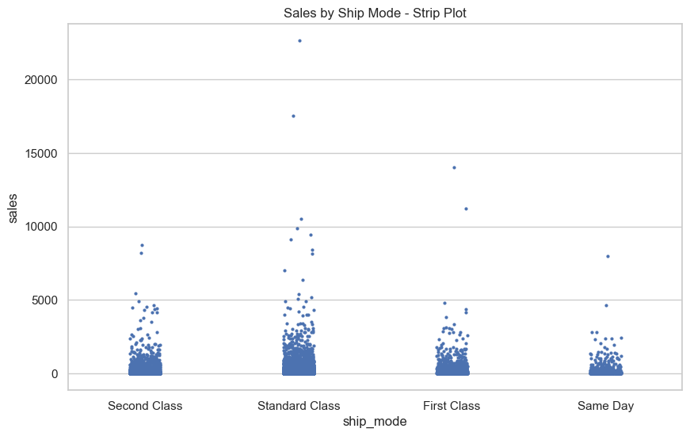

```python
sns.stripplot(data=df, x='ship_mode', y='sales', jitter=True, size=3)
plt.title("Sales by Ship Mode - Strip Plot")
plt.show()
```

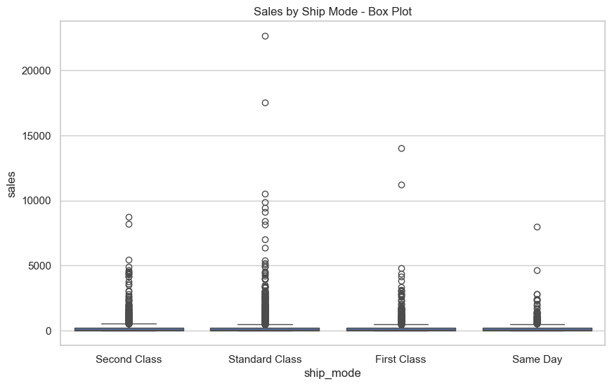

```python
sns.boxplot(data=df, x='ship_mode', y='sales')
plt.title("Sales by Ship Mode - Box Plot")
plt.show()
```

## 🎯 Categorical vs Numerical

- *What:* Compare numerical values across different categories.
- *Why:* To understand how numerical metrics vary between groups.
- *When to use:* When evaluating group-wise trends, e.g. profit by segment.

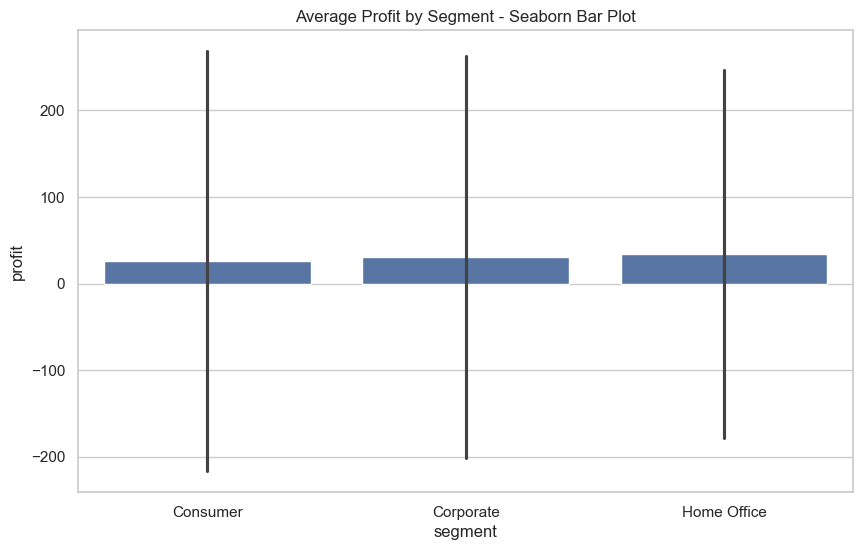

```python
sns.barplot(data=df, x='segment', y='profit', estimator='mean', ci='sd')
plt.title("Average Profit by Segment - Seaborn Bar Plot")
plt.show()
```

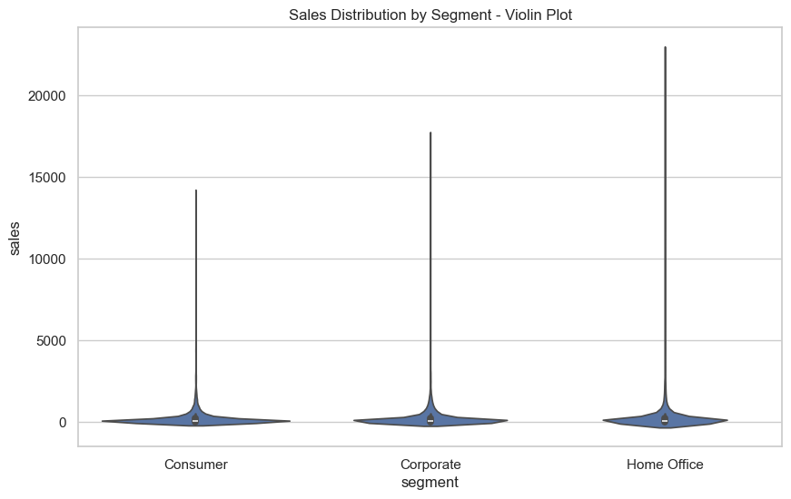

```python
sns.violinplot(data=df, x='segment', y='sales')
plt.title("Sales Distribution by Segment - Violin Plot")
plt.show()
```

```python
fig = px.box(df, x='category', y='profit', color='category',
             title="Profit by Category - Plotly Box Plot")
fig.show()
```

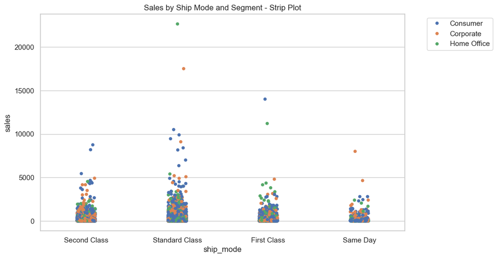

```python
sns.stripplot(data=df, x='ship_mode', y='sales', jitter=True, hue='segment')
plt.title("Sales by Ship Mode and Segment - Strip Plot")
plt.legend(bbox_to_anchor=(1.05, 1), loc='upper left')
plt.show()
```

📌 **Insight:** Consumer segment shows more profit variance; standard ship mode is used across all segments.

## 🧩 Categorical vs Categorical

- *What:* Show relationships between two categorical variables.
- *Why:* To visualize frequency or interaction patterns.
- *When to use:* For category overlap, usage, and frequency comparisons.

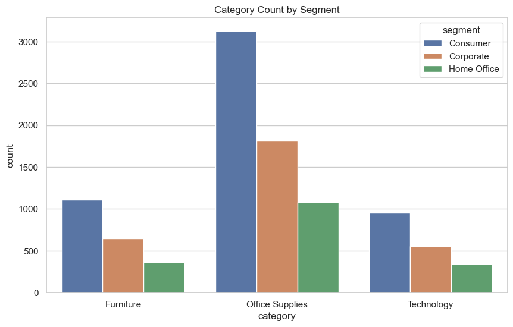

```python
sns.countplot(data=df, x='category', hue='segment')
plt.title("Category Count by Segment")
plt.show()
```

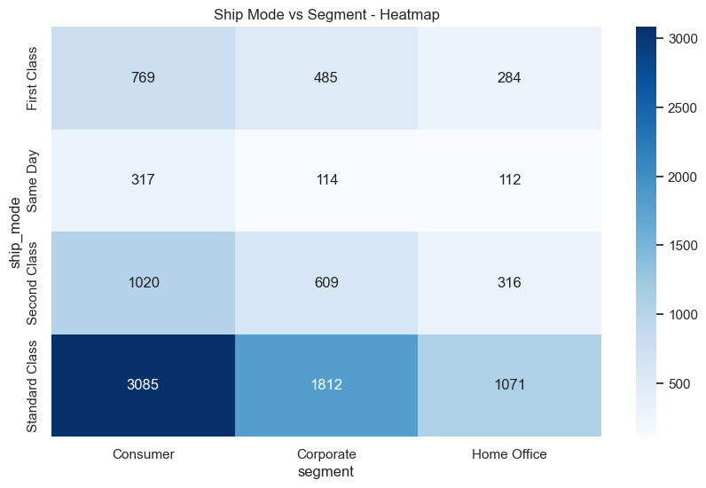

```python
cross = pd.crosstab(df['ship_mode'], df['segment'])
sns.heatmap(cross, annot=True, fmt='d', cmap='Blues')
plt.title("Ship Mode vs Segment - Heatmap")
plt.show()
```

```python
grouped = df.groupby(['segment', 'ship_mode']).size().reset_index(name='count')
fig = px.bar(grouped, x='ship_mode', y='count', color='segment', barmode='group',
             title="Shipment Mode by Segment - Plotly")
fig.show()
```

# 🔗 Chapter 4: Multivariate Analysis

### 🎯 Goal:

Visualize and analyze relationships involving **three or more variables** to uncover complex interactions and deeper insights.

We will use:

- Colored scatter plots
- Faceted plots
- Pair plots
- Heatmaps
- Treemaps

Using **Matplotlib**, **Seaborn**, and **Plotly Express**

## 🎨 Colored Scatter Plot

- *What:* A scatter plot with an additional variable shown via color or size.
- *Why:* To visualize interactions between three numerical or mixed-type variables.
- *When to use:* To detect clusters, patterns, or anomalies affected by a third variable.

```python
fig = px.scatter(df, x='sales', y='profit', color='segment', size='discount',
                 title="Sales vs Profit by Segment (Size = Discount)")
fig.show()
```

📌 **Insight:** Profitability varies across segments. Larger discounts often associate with losses.

## 🔁 Pair Plot

- *What:* A grid of scatter plots showing all variable combinations.
- *Why:* To explore all pairwise relationships at once.
- *When to use:* During exploratory analysis to screen for trends or correlations.

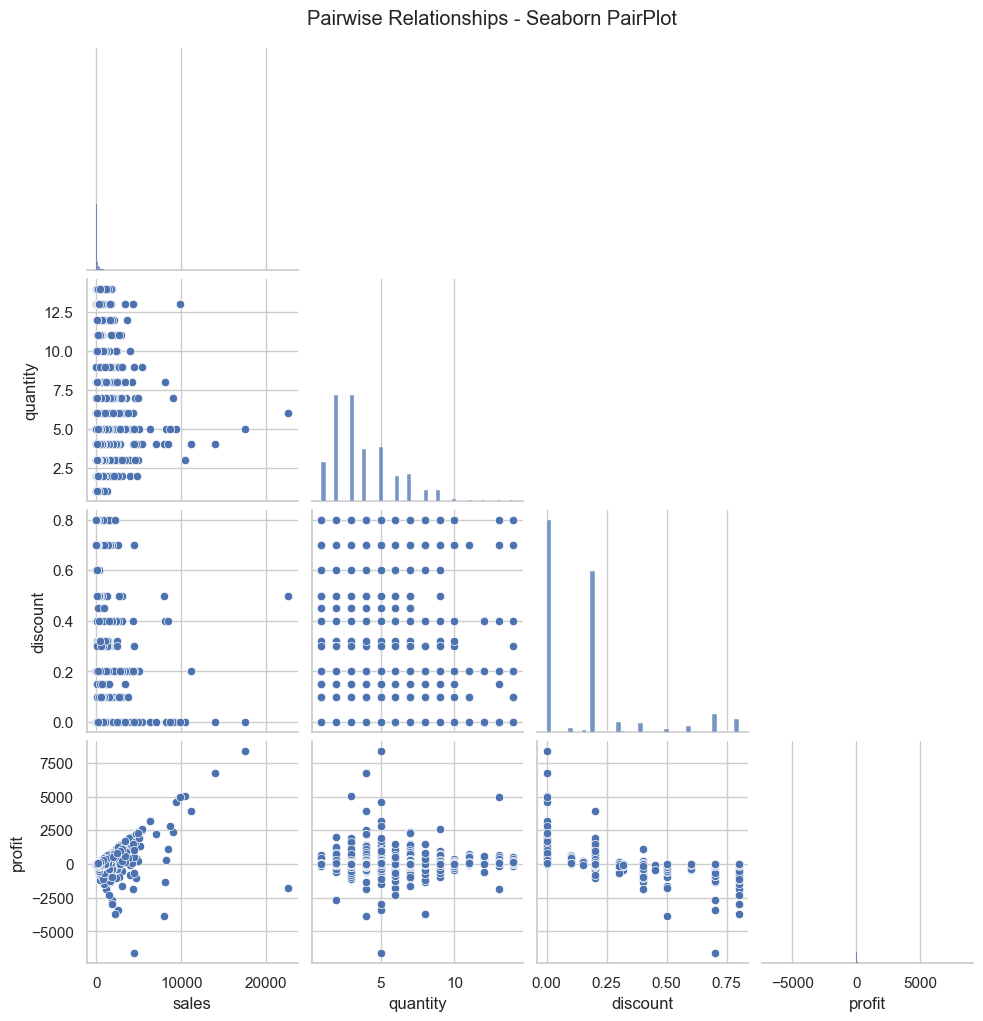

```python
sns.pairplot(df[['sales', 'quantity', 'discount', 'profit']], corner=True)
plt.suptitle("Pairwise Relationships - Seaborn PairPlot", y=1.02)
plt.show()
```

📌 **Insight:** Sales and Profit have wide variance; Discount shows negative trends with Profit.

## 🧩 Faceted Plot

- *What:* A set of subplots created for each level of a categorical variable.
- *Why:* To compare distributions or trends across subgroups.
- *When to use:* When comparing the same plot across multiple categories.

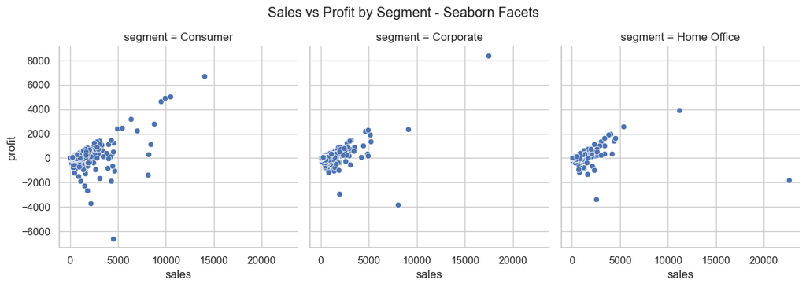

```python
g = sns.FacetGrid(df, col="segment", height=4)
g.map_dataframe(sns.scatterplot, x="sales", y="profit")
g.fig.suptitle("Sales vs Profit by Segment - Seaborn Facets", y=1.05)
plt.show()
```

```python
fig = px.scatter(df, x='sales', y='profit', facet_col='category',
                 color='ship_mode', title="Sales vs Profit Faceted by Category - Plotly")
fig.show()
```

📌 **Insight:** Technology has wider spread in profit/sales; furniture more tightly clustered.

## 🧯 Category Heatmap

- *What:* A pivot-table-style heatmap using two categorical variables.
- *Why:* To detect interaction effects between categories.
- *When to use:* To find category combinations with high or low values.

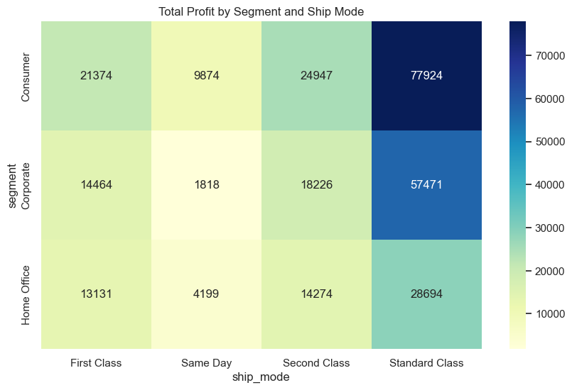

```python
pivot = df.pivot_table(index='segment', columns='ship_mode', values='profit', aggfunc='sum')
sns.heatmap(pivot, annot=True, fmt='.0f', cmap='YlGnBu')
plt.title("Total Profit by Segment and Ship Mode")
plt.show()
```

```python
fig = px.imshow(pivot, text_auto=True, title="Profit by Segment and Ship Mode - Plotly")
fig.show()
```

## 🌳 Treemap

- *What:* A hierarchical visualization using nested rectangles.
- *Why:* To understand part-to-whole across multiple categorical levels.
- *When to use:* For high-cardinality hierarchical categories with numerical values.

```python
fig = px.treemap(df, path=['category', 'sub_category'], values='sales',
                 color='profit', title="Sales & Profit by Category/Sub-Category")
fig.show()
```

📌 **Insight:** Office Supplies has wide product spread. Some sub-categories have strong profit margins.

## 🫧 Bubble Chart

- **What:** A scatter plot where each point has a third dimension represented by the size of the marker.
- **Why:** Useful to show relationships between three continuous variables.
- **When to use:** When you want to show how size varies in a two-dimensional plot.

```python
import plotly.express as px
fig = px.scatter(df, x='sales', y='profit', size='quantity', color='category',
                 title="Bubble Chart: Sales vs Profit (Size = Quantity, Color = Category)")
fig.show()
```

📌 **Insight:** Technology has larger sales-profit outliers; some categories have low profit despite high sales.

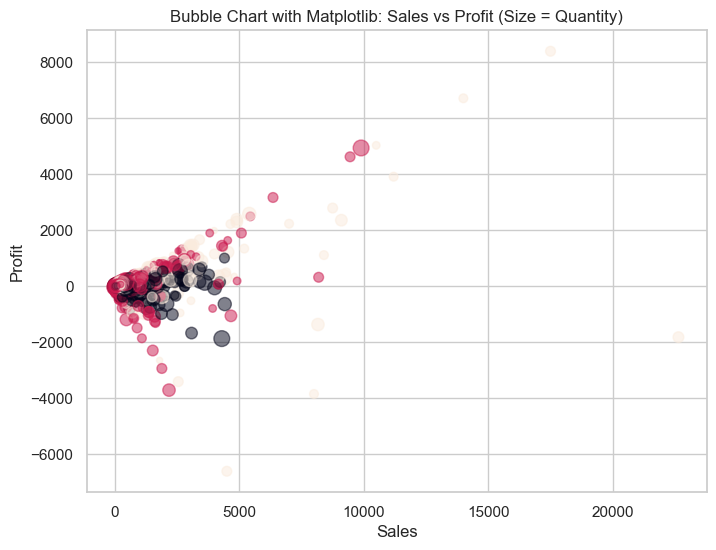

```python
plt.figure(figsize=(8,6))
scatter = plt.scatter(df['sales'], df['profit'], s=df['quantity']*10, alpha=0.5, c=pd.factorize(df['category'])[0])
plt.xlabel("Sales")
plt.ylabel("Profit")
plt.title("Bubble Chart with Matplotlib: Sales vs Profit (Size = Quantity)")
plt.show()
```

## 🏞️ Area Plot

- **What:** A line plot with the area below filled with color.
- **Why:** Helps visualize cumulative totals or trends over time.
- **When to use:** When showing how a quantity changes cumulatively or over categories.

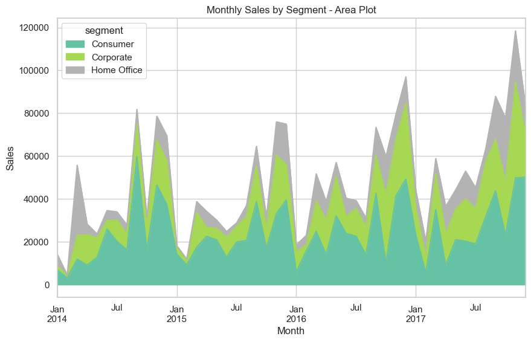

```python
df_month = df.copy()
df_month['order_month'] = df_month['order_date'].dt.to_period('M')
area_data = df_month.groupby(['order_month', 'segment'])['sales'].sum().unstack().fillna(0)
area_data.plot.area(figsize=(10,6), cmap='Set2', title='Monthly Sales by Segment - Area Plot')
plt.ylabel("Sales")
plt.xlabel("Month")
plt.show()
```

📌 **Insight:** Consumer segment consistently dominates sales volume over time.

```python
df_area = df.groupby(['order_date', 'category'])['sales'].sum().reset_index()
fig = px.area(df_area, x='order_date', y='sales', color='category', title="Sales Over Time by Category - Plotly Area Plot")
fig.show()
```

## 🧱 Subplots

- **What:** Multiple plots displayed in a single figure layout.
- **Why:** Useful for comparing distributions or trends across multiple groups.
- **When to use:** When visualizing multiple relationships side-by-side for context.

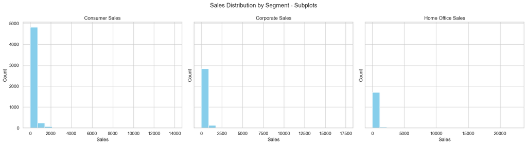

```python
fig, axes = plt.subplots(1, 3, figsize=(18, 5), sharey=True)
segments = df['segment'].unique()
for i, seg in enumerate(segments):
    seg_data = df[df['segment'] == seg]
    axes[i].hist(seg_data['sales'], bins=20, color='skyblue')
    axes[i].set_title(f"{seg} Sales")
    axes[i].set_xlabel("Sales")
    axes[i].set_ylabel("Count")
plt.suptitle("Sales Distribution by Segment - Subplots")
plt.tight_layout()
plt.show()
```

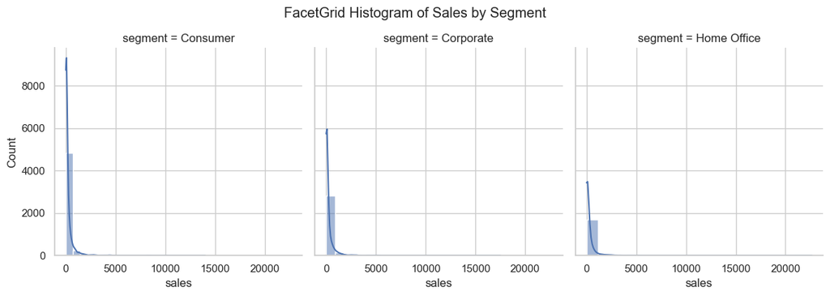

```python
g = sns.FacetGrid(df, col="segment", col_wrap=3, height=4)
g.map_dataframe(sns.histplot, x="sales", bins=20, kde=True)
g.fig.suptitle("FacetGrid Histogram of Sales by Segment", y=1.05)
plt.show()
```

## ☁️ Word Cloud

### 🔍 What is it?

A word cloud is a visual representation of text data, where the size of each word indicates its frequency or importance.

### ❓ When to use it?

- To visualize dominant keywords or repeated entries
- For quick EDA of textual features

### 📈 Example: Most Frequent Product Names

```python
# !pip install wordcloud
```

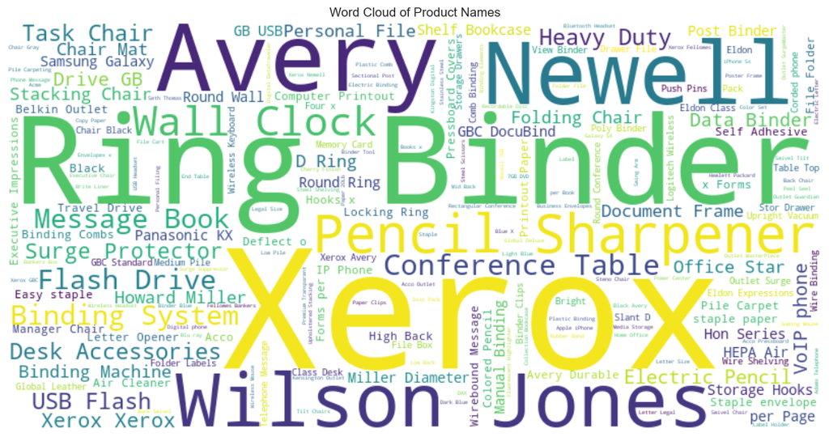

```python
from wordcloud import WordCloud
import matplotlib.pyplot as plt

text = ' '.join(df['product_name'].dropna().astype(str).tolist())

wordcloud = WordCloud(width=800, height=400, background_color='white').generate(text)

plt.figure(figsize=(14, 7))
plt.imshow(wordcloud, interpolation='bilinear')
plt.axis('off')
plt.title('Word Cloud of Product Names')
plt.show()
```

## 🧱 Subplots

### 🔍 What is it?

Subplots allow multiple plots to be displayed in a single figure layout (grid-style).

### ❓ When to use it?

- To compare multiple visualizations side by side
- To save space and show relationships between metrics

### 📈 Example: Compare Sales and Profit by Segment

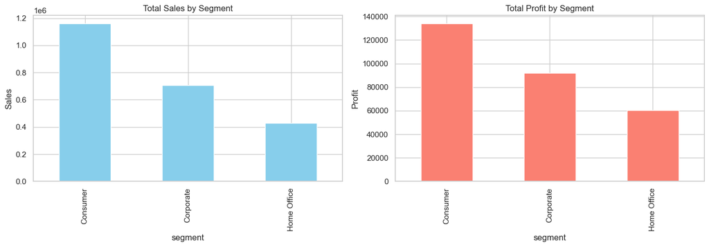

```python
fig, axes = plt.subplots(1, 2, figsize=(14, 5))

# Sales by Segment
df.groupby('segment')['sales'].sum().plot(kind='bar', ax=axes[0], color='skyblue')
axes[0].set_title('Total Sales by Segment')
axes[0].set_ylabel('Sales')

# Profit by Segment
df.groupby('segment')['profit'].sum().plot(kind='bar', ax=axes[1], color='salmon')
axes[1].set_title('Total Profit by Segment')
axes[1].set_ylabel('Profit')

plt.tight_layout()
plt.show()
```

## 📌 Final Summary

In this tutorial, we visualized key patterns and relationships in the Superstore dataset using:

- 📊 Matplotlib for basic static charts
- 🎨 Seaborn for enhanced statistical plots
- 🌐 Plotly for interactive visuals

Data visualization is essential for:

- Communicating insights clearly
- Validating assumptions
- Supporting decision making

Keep practicing by trying these charts on other datasets!